# Stock return: HMM and HSMM

Matteo Fasulo, Simone Flavio Paris, Matteo Sivoccia

18/12/2021

# 1 Introduzione

## 1.1 Librerie utilizzate

```r
load(url("https://github.com/smoxy/DMANA-proj/blob/main/HMM-HSMM/code/Examples_L31.RData?raw=true"))
source("https://raw.githubusercontent.com/MatteoFasulo/Rare-Earth/main/R/util/coreFunctions.R")
loadPackages(c('ggplot2','gamlss','tidyverse','tidyquant','magrittr',
               'tseries','MVN','mhsmm','doParallel','pacman','gridExtra'))
rm(returns)
rm(pollution)
rm(stock.names)
pacman::p_loaded()
```

```
 [1] "gridExtra"            "pacman"
 [3] "doParallel"           "iterators"
 [5] "foreach"              "mhsmm"
 [7] "mvtnorm"              "MVN"
 [9] "tseries"              "magrittr"
[11] "tidyquant"            "quantmod"
[13] "TTR"                  "PerformanceAnalytics"
[15] "xts"                  "zoo"
[17] "lubridate"            "forcats"
[19] "stringr"              "dplyr"
[21] "purrr"                "readr"
[23] "tidyr"                "tibble"
[25] "tidyverse"            "gamlss"
[27] "nlme"                 "gamlss.dist"
[29] "MASS"                 "gamlss.data"
[31] "ggplot2"
```

## 1.2 Descrizione

- **NASDAQ**: *National Association of Securities Dealers Automated Quotation* misura le **100 società** del settore tecnologico, delle telecomunicazioni, della biotecnologia ma anche da società del commercio sia al dettaglio e sia all’ingrosso.
- **ESTX50**: *EURO STOXX 50* è anch’esso un indice azionario di titoli che comprende una rappresentazione dei principali settori industriali dell’area. È composto da **50 titoli** degli 11 paesi dell’**eurozona**: Austria, Belgio, Finlandia, Francia, Germania, Irlanda, Italia, Lussemburgo, Paesi Bassi, Portogallo e Spagna.
- **FTSE**: *Financial Times Stock Exchange Milano Indice di Borsa* è il più significativo indice azionario della Borsa Italiana. È il paniere che racchiude di norma, tranne eccezioni, le azioni delle **40 società italiane**, anche se hanno la sede legale all’estero, quotate sull’MTA o sul MIV con maggiore capitalizzazione, flottante e liquidità che rappresentano oltre l’80% della capitalizzazione complessiva e quasi il 90% del controvalore degli scambi.
- **SP500**: *Standard & Poor 500* è un indice che racchiude tutte le **500 aziende statunitensi** con la più alta capitalizzazione di mercato, quindi ovviamente il NASDAQ è un sottoinsieme di questo paniere

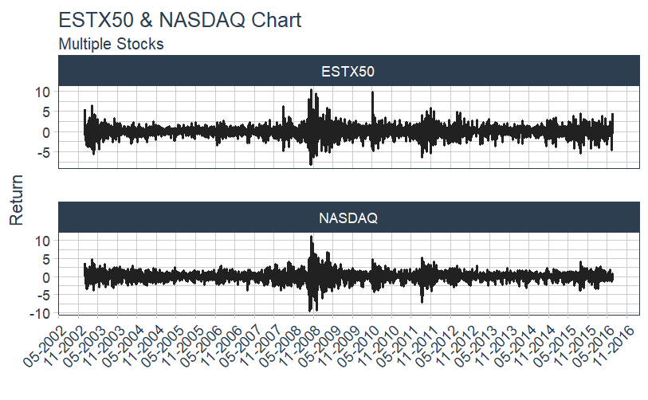

```r
dfStruct <- function(dataframe){
  dates <- dataframe$Date
  #SP500 <- dataframe$SP500
  NASDAQ <- dataframe$NASDAQ
  #FTSE <- dataframe$FTSE
  ESTX50 <- dataframe$ESTX50

  name <- rep(c("NASDAQ","ESTX50"),times=c(nrow(dataframe),nrow(dataframe)))
  dates <- rep(dates, times=2)
  value <- rep(c(NASDAQ,ESTX50))

  df <- data.frame("name"=name,
                       "date"=as.Date(dates,format="%d/%m/%Y"),
                       "value"=value)
  return(df)
}

Stocks <- dfStruct(StockReturns2)

Stocks %>%
  ggplot(., aes(x=date, y=value, group=name))+
    geom_line(size=.75, col="gray13") +
    scale_x_date(date_labels = "%m-%Y", date_breaks="6 months") +
    facet_wrap(~ name, ncol = 1, scale = "free_y") +
    labs(title = "ESTX50 & NASDAQ Chart",
         subtitle = "Multiple Stocks",
         y = "Return",
         x = "") +
    theme_tq()+
    theme(axis.text.x = element_text(angle = 45, hjust = 1))
```

Si nota come vi siano stati periodi con molta volatilità:

- Ottobre/Novembre 2008
- Maggio 2010
- Luglio 2011
- Settembre 2015

## 1.3 Statistiche descrittive

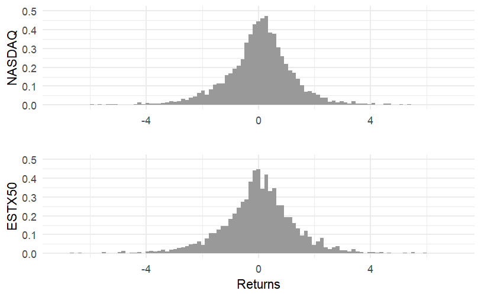

| name | Mean | Std. dev | Skewness | Kurtosis | Jarque–Bera test (p-value) |
| --- | --- | --- | --- | --- | --- |
| ESTX50 | 0.014 | 1.439172 | 0.05469118 | 5.039420 | 3591 (0) |
| NASDAQ | 0.038 | 1.328035 | -0.21513458 | 6.566296 | 6119.9 (0) |

## 1.4 Verifica dei risultati ottenuti dalle statistiche descrittive

```r
par(mfrow=c(1,3))
qqnorm(StockReturns2$NASDAQ)
qqline(StockReturns2$NASDAQ)
```

```r
qqnorm(StockReturns2$ESTX50)
qqline(StockReturns2$ESTX50)
```

| Test | Statistic | p value | Result |
| --- | --- | --- | --- |
| Mardia Skewness | 116.797159467314 | 2.57985401519554e-24 | NO |
| Mardia Kurtosis | 111.118772102122 | 0 | NO |
| MVN | NA | NA | NO |

|  | Test | Variable | Statistic | p value | Normality |
| --- | --- | --- | --- | --- | --- |
| 1 | Anderson-Darling | NASDAQ | 42.7702 | <0.001 | NO |
| 2 | Anderson-Darling | ESTX50 | 36.0651 | <0.001 | NO |

|  | n | Mean | Std.Dev | Median | Min | Max | 25th | 75th | Skew | Kurtosis |
| --- | --- | --- | --- | --- | --- | --- | --- | --- | --- | --- |
| NASDAQ | 3392 | 0.03791923 | 1.328035 | 0.09132206 | -9.587695 | 11.15944 | -0.5629222 | 0.6928949 | -0.2150395 | 6.560656 |
| ESTX50 | 3392 | 0.01417332 | 1.439172 | 0.02659246 | -8.207879 | 10.43765 | -0.6753727 | 0.7409396 | 0.0546670 | 5.034681 |

```
NA
```

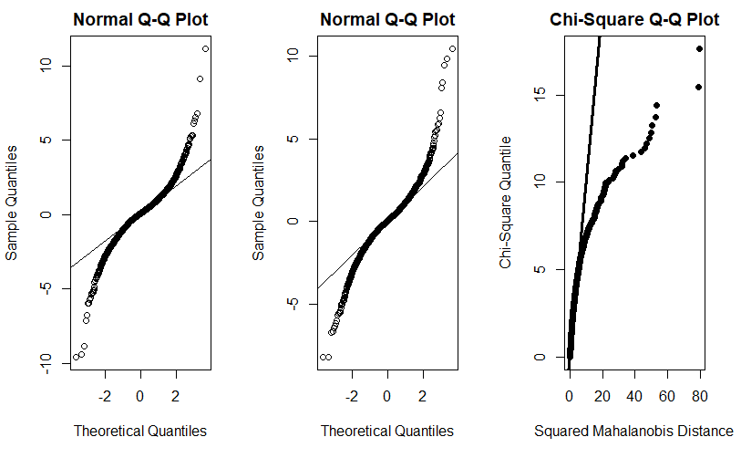

```r
mvn(StockReturns2[,-c(1,4,5)],mvnTest="mardia",multivariatePlot="qq")
```

# 2 HMM

Per modellare l’andamento dei ritorni, abbiamo utilizzato diversi **Hidden Markov Model** con un numero di stati compreso tra 2 e 4. La distribuzione di emissione selezionata è la Normale, mentre i parametri di emissione sono generati dal K-Means. Il vettore degli stati iniziali contiene tutte probabilità uguali esattamente come la matrice di transizione. Per la complessità computazionale del caso, abbiamo ritenuto opportuno parallelizzare il problema riducendo ogni core all’elaborazione di un modello con *n* stati. Avremo dunque 3 core che elaborano parallelamente il modello con 2, 3 e 4 stati. Nel tentativo di introdurre un’incertezza associata alla stima dei parametri delle nostre misture, ci è sembrato opportuno applicare un **Bootstrap Parametrico**.

## 2.1 Parallel Bootstrap

```r
newDF <- StockReturns2[,-c(1,4,5)]
bootstrap.N.HMM = function(data, states, R){
  master = list()
  cores <- ifelse(detectCores()>6,
                  cores <- 6,
                  cores <- 4)
  cl <- makeCluster(cores)
  registerDoParallel(cl)
  master<-append(master,foreach(num = 2:states) %dopar% {
    require(mhsmm)

    hsmmAIC <- function(model){
      if (class(model)=='hmm'){
        m = model$K
      } else if (class(model)=='hsmm'){
        m = model$J
      }
      k = length(model$model$parms.emission)
      p = m^2 + (k*m) - 1
      logL = max(model$loglik)
      AIC = (2 * logL) + (2*p)
      return(AIC)
    }

    hsmmBIC <- function(model){
      if (class(model)=='hmm'){
        m = model$K
      } else if (class(model)=='hsmm'){
        m = model$J
      }
      nObs = length(model$yhat)
      k = length(model$model$parms.emission)
      p = (m^2 + (k*m)) - 1
      logL = max(model$loglik)
      BIC = (2 * logL) + (p*log(nObs))
      return(BIC)
    }

    initialization <- kmeans(data,num)
    kmeans.means <- initialization$centers
    km.means.list = list()
    sigma = list()
    for (n in 1:num){
      sigma[[n]] = cov(data[initialization$cluster==n,])
      km.means.list[[n]] = kmeans.means[n,]
    }
    K <- num
    start.val <- hmmspec(init = rep(1/K, K),
                         trans = matrix(1/K, nrow = K, ncol = K),
                         parms.emis = list(mu=km.means.list,
                                           sigma=sigma),
                         dens.emis = dmvnorm.hsmm)
    mod.hmm <- hmmfit(matrix(unlist(data),ncol=2),
                      start.val, mstep = mstep.mvnorm)
    mu.boot <- matrix(NA,K*2,R)
    sigma.boot <- matrix(NA,K*4,R)
    for (b in 1:R)
    {
      true.par <- hmmspec(init = mod.hmm$model$init,
                          trans = mod.hmm$model$transition,
                          parms.emis = list(mu = mod.hmm$model$parms.emission$mu,
                                            sigma = mod.hmm$model$parms.emission$sigma),
                          dens.emis = dmvnorm.hsmm)
      mod.boot <- hmmfit(matrix(unlist(data)), true.par, mstep = mstep.mvnorm)
      mu.boot[,b] <- unlist(mod.boot$model$parms.emission$mu)
      sigma.boot[,b] <- unlist(mod.boot$model$parms.emission$sigma)
    }

    return(list(k = num,
                model = mod.hmm,
                means.mean = t(matrix(apply(mu.boot,1,mean),ncol = K*2)),
                means.sd = t(matrix(apply(mu.boot,1,sd),ncol = K*2)),
                sigma.mean = t(matrix(apply(sigma.boot,1,mean),ncol = K*2**2)),
                sigma.sd = t(matrix(apply(sigma.boot,1,sd),ncol = K*2**2)),
                AIC=hsmmAIC(mod.hmm),
                BIC=hsmmBIC(mod.hmm)))

  },length(master))
  stopCluster(cl)
  return(master)
}

load("Z:/DesktopC/LUMSA/2/Data Mining/HMM-HSMM/data/N-HMM-2-4.RData")
```

A riconferma del fatto che la complessità computazionale non fosse banale, il grafico della log likelihood in funzione delle iterazioni dell’algoritmo EM, mostra come all’aumentare del numero di stati, la convergenza sia sempre più lenta e necessiti di più iterazioni.

```r
par(mfrow=c(3,1))
plot(HMM[[1]]$model$loglik,
     type = "b",
     ylab="Log-likelihood",
     xlab="Iteration",
     xlim=c(0,30),
     main="2 states LogLik")
plot(HMM[[2]]$model$loglik,
     type = "b",
     ylab = "Log-likelihood",
     xlab="Iteration",
     xlim=c(0,30),
     main="3 states LogLik")
```

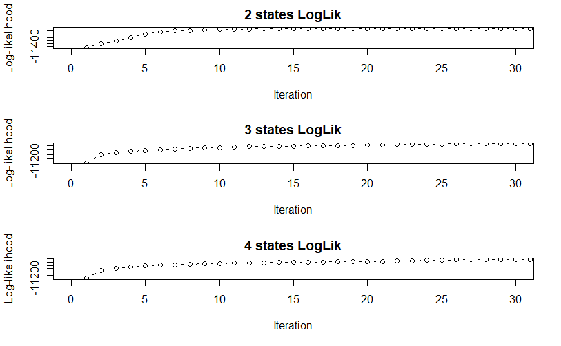

```r
plot(HMM[[3]]$model$loglik,
     type = "b",
     ylab = "Log-likelihood",
     xlab="Iteration",
     xlim=c(0,30),
     main="4 states LogLik")
```

Andando a vedere le osservazioni per ogni stato di appartenenza, si nota come:

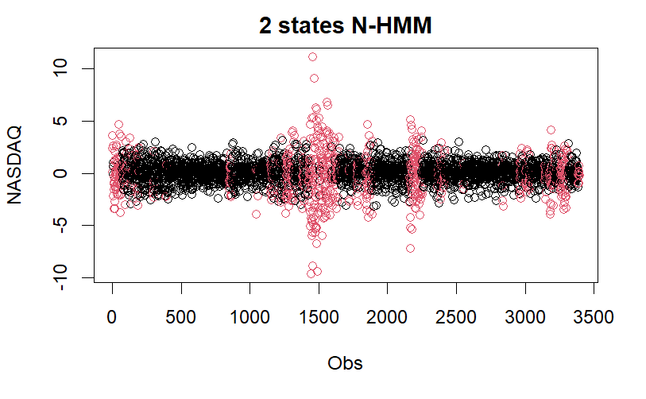

```r
plot(newDF[,1],
     col=HMM[[1]]$model$yhat,
     main = "2 states N-HMM",
     xlab="Obs",
     ylab=colnames(newDF)[1])
```

```r
HMM[[1]]$model$model$transition
```

```
           [,1]       [,2]
[1,] 0.98113176 0.01886824
[2,] 0.06206001 0.93793999
```

```r
colSums(HMM[[1]]$model$model$transition)/2
```

```
[1] 0.5215959 0.4784041
```

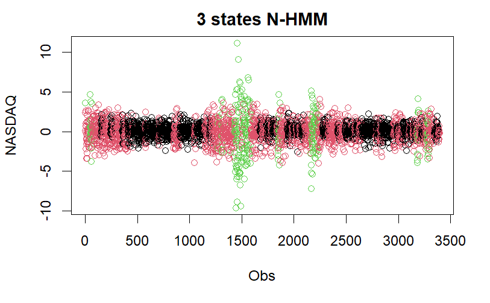

```r
plot(newDF[,1],
     col=HMM[[2]]$model$yhat,
     main = "3 states N-HMM",
     xlab="Obs",
     ylab=colnames(newDF)[1])
```

```r
HMM[[2]]$model$model$transition
```

```
             [,1]       [,2]          [,3]
[1,] 9.613597e-01 0.03864034 1.372944e-100
[2,] 4.046146e-02 0.95135951  8.179028e-03
[3,] 3.212634e-76 0.04054786  9.594521e-01
```

```r
colSums(HMM[[2]]$model$model$transition)/3
```

```
[1] 0.3339404 0.3435159 0.3225437
```

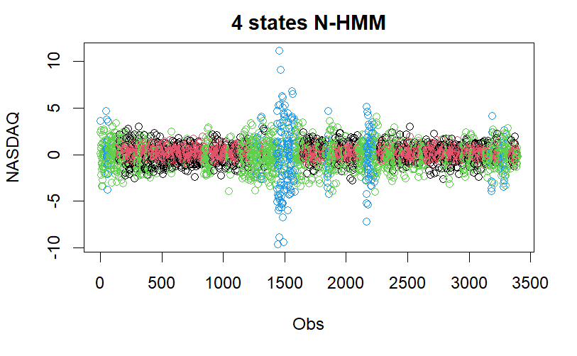

```r
plot(newDF[,1],
     col=HMM[[3]]$model$yhat,
     main = "4 states N-HMM",
     xlab="Obs",
     ylab=colnames(newDF)[1])
```

```r
HMM[[3]]$model$model$transition
```

```
           [,1]         [,2]        [,3]        [,4]
[1,] 0.12949405 8.667148e-01 0.003791154 0.000000000
[2,] 0.51784575 4.254954e-01 0.056658879 0.000000000
[3,] 0.05004845 2.925648e-24 0.940929615 0.009021937
[4,] 0.00000000 0.000000e+00 0.043077364 0.956922636
```

```r
colSums(HMM[[3]]$model$model$transition)/4
```

```
[1] 0.1743471 0.3230525 0.2611143 0.2414861
```

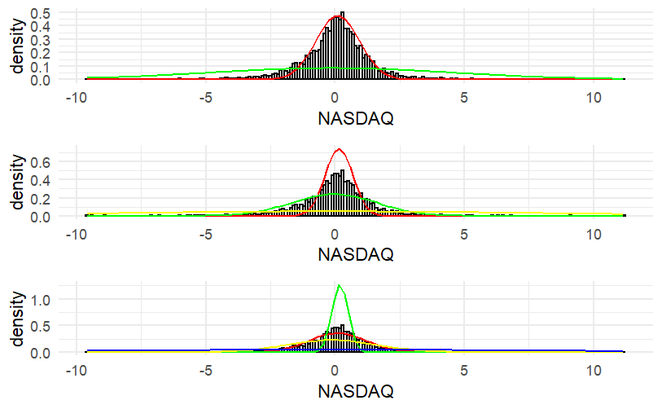

```r
p1<-ggplot(StockReturns2, aes(x=NASDAQ)) +
  geom_histogram(aes(y =..density..),
                 color="black", fill="white", binwidth=.1) +
  theme_minimal()+
  stat_function(fun = dnorm, args = list(mean = HMM[[1]]$means.mean[1],
                                         sd = HMM[[1]]$sigma.mean[1]), colour="red")+
  stat_function(fun = dnorm, args = list(mean = HMM[[1]]$means.mean[3],
                                         sd = HMM[[1]]$sigma.mean[5]), colour="green")

p2<-ggplot(StockReturns2, aes(x=NASDAQ)) +
  geom_histogram(aes(y =..density..),
                 color="black", fill="white", binwidth=.1) +
  theme_minimal()+
  stat_function(fun = dnorm, args = list(mean = HMM[[2]]$means.mean[1],
                                         sd = HMM[[2]]$sigma.mean[1]), colour="red")+
  stat_function(fun = dnorm, args = list(mean = HMM[[2]]$means.mean[3],
                                         sd = HMM[[2]]$sigma.mean[5]), colour="green")+
  stat_function(fun = dnorm, args = list(mean = HMM[[2]]$means.mean[5],
                                         sd = HMM[[2]]$sigma.mean[9]), colour="yellow")

p3<-ggplot(StockReturns2, aes(x=NASDAQ)) +
  geom_histogram(aes(y =..density..),
                 color="black", fill="white", binwidth=.1) +
  theme_minimal()+
  stat_function(fun = dnorm, args = list(mean = HMM[[3]]$model$model$parms.emission$mu[[1]][1],
                                         sd = HMM[[3]]$model$model$parms.emission$sigma[[1]][1]), colour="red")+
  stat_function(fun = dnorm, args = list(mean = HMM[[3]]$model$model$parms.emission$mu[[2]][1],
                                         sd = HMM[[3]]$model$model$parms.emission$sigma[[2]][1]), colour="green")+
  stat_function(fun = dnorm, args = list(mean = HMM[[3]]$model$model$parms.emission$mu[[3]][1],
                                         sd = HMM[[3]]$model$model$parms.emission$sigma[[3]][1]), colour="yellow")+
  stat_function(fun = dnorm, args = list(mean = HMM[[3]]$model$model$parms.emission$mu[[4]][1],
                                         sd = HMM[[3]]$model$model$parms.emission$sigma[[4]][1]), colour="blue")

grid.arrange(p1, p2, p3, ncol=1)
```

# 3 HSMM

Come nel **HMM** abbiamo scelto la *Normale* come ED, inizializzato gli stati con un vettore di probabilità uguali, applicato il K-Means per i parametri di emissione e utilizzato come SD sia la Poisson (shifted) che la Gamma. La matrice di transizione è stata modellata come segue:

```r
K <- 3
P <- matrix(1 / (K - 1), ncol = K, nrow = K)
diag(P) <- 0
```

## 3.1 Poisson SD

```r
bootstrap.N.HSMM.POISSON <- function(data, states, R) {
  master = list()
  cores <- ifelse(detectCores() > 6,
                  cores <- 3,
                  cores <- 3)
  cl <- makeCluster(cores)
  registerDoParallel(cl)
  master <- append(master, foreach(num = 2:states) %dopar% {
    require(mhsmm)

    hsmmAIC <- function(model) {
      if (class(model) == 'hmm') {
        m = model$K
      } else if (class(model) == 'hsmm') {
        m = model$J
      }
      k = length(model$model$parms.emission)
      p = m ^ 2 + (k * m) - 1
      logL = max(model$loglik)
      AIC = (2 * logL) + (2 * p)
      return(AIC)
    }

    hsmmBIC <- function(model) {
      if (class(model) == 'hmm') {
        m = model$K
      } else if (class(model) == 'hsmm') {
        m = model$J
      }
      nObs = length(model$yhat)
      k = length(model$model$parms.emission)
      p = (m ^ 2 + (k * m)) - 1
      logL = max(model$loglik)
      BIC = (2 * logL) + (p * log(nObs))
      return(BIC)
    }

    initialization <- kmeans(data, num)
    kmeans.means <- initialization$centers
    km.means.list = list()
    sigma.list = list()

    for (n in 1:num) {
      sigma.list[[n]] = cov(data[initialization$cluster == n, ])
      km.means.list[[n]] = kmeans.means[n, ]
    }

    K <- num
    init <- rep(1 / K, K)
    P <- matrix(1 / (K - 1), ncol = K, nrow = K)
    diag(P) <- 0
    B <- list(mu = km.means.list,
              sigma = sigma.list)

    d <-list(
      lambda = sample(1:500, K),
      shift = sample(10:100, K),
      type = "poisson")

    start.val <- hsmmspec(
      init = init,
      transition = P,
      parms.emis = B,
      sojourn = d,
      dens.emis = dmvnorm.hsmm,
      mstep = mstep.mvnorm)

    mod.hsmm <- hsmmfit(matrix(unlist(data),ncol = 2), start.val, mstep = mstep.mvnorm)
    mu.boot <- matrix(NA, K * 2, R)
    sigma.boot <- matrix(NA, K * 4, R)
    for (b in 1:R){
      true.par <- hsmmspec(
        init = mod.hsmm$model$init,
        transition = mod.hsmm$model$transition,
        parms.emis = list(
          mu = mod.hsmm$model$parms.emission$mu,
          sigma = mod.hsmm$model$parms.emission$sigma),
        sojourn = list(
          lambda = mod.hsmm$model$sojourn$lambda,
          shift = mod.hsmm$model$sojourn$shift,
          type = mod.hsmm$model$sojourn$type),
        dens.emis = dmvnorm.hsmm,
        mstep = mstep.mvnorm)

      train <- simulate(true.par, nsim = 100, seed = b, rand.emis = rmvnorm.hsmm)

      mod.boot <- hsmmfit(train, true.par, mstep = mstep.mvnorm)
      mu.boot[, b] <- unlist(mod.boot$model$parms.emission$mu)
      sigma.boot[, b] <- unlist(mod.boot$model$parms.emission$sigma)
    }

    return(list(
      k = num,
      model = mod.hsmm,
      means.mean = t(matrix(apply(mu.boot, 1, mean), ncol = K * 2)),
      means.sd = t(matrix(apply(mu.boot, 1, sd), ncol = K * 2)),
      sigma.mean = t(matrix(apply(sigma.boot, 1, mean), ncol = K * 2 ** 2)),
      sigma.sd = t(matrix(apply(sigma.boot, 1, sd), ncol = K * 2 ** 2)),
      AIC = hsmmAIC(mod.hsmm),
      BIC = hsmmBIC(mod.hsmm)))
  }, length(master))

  stopCluster(cl)
  return(master)
}
load("~/N-HSMM-2-4-Poisson.RData")
```

```r
par(mfrow=c(3,1))
plot(HSMM[[1]]$model$loglik,
     type = "b",
     ylab="Log-likelihood",
     xlab="Iteration",
     xlim=c(0,30),
     main="2 states LogLik")
plot(HSMM[[2]]$model$loglik,
     type = "b",
     ylab = "Log-likelihood",
     xlab="Iteration",
     xlim=c(0,30),
     main="3 states LogLik")
```

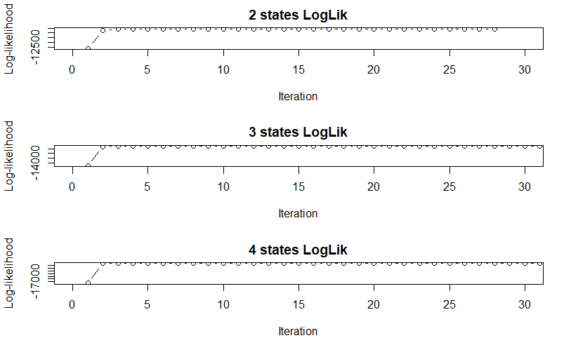

```r
plot(HSMM[[3]]$model$loglik,
     type = "b",
     ylab = "Log-likelihood",
     xlab="Iteration",
     xlim=c(0,30),
     main="4 states LogLik")
```

```r
par(mfrow=c(3,1))
plot(HSMM[[1]]$model,xlim=c(0,550))
plot(HSMM[[2]]$model,xlim=c(0,550))
```

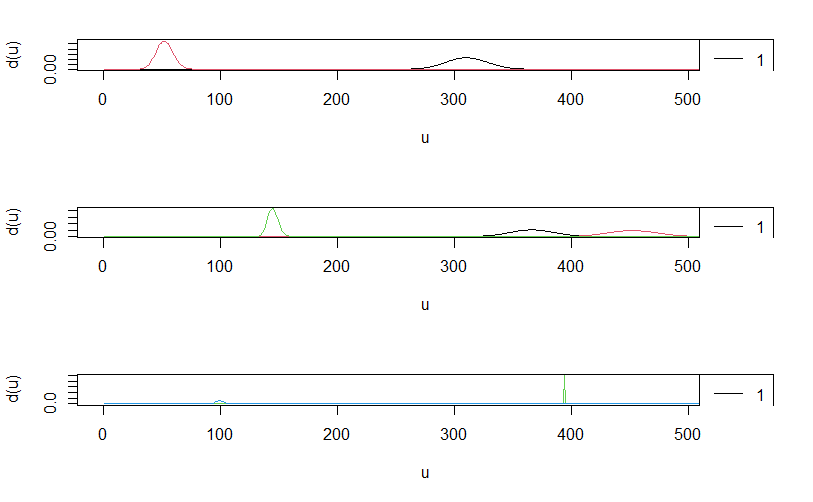

```r
plot(HSMM[[3]]$model,xlim=c(0,550))
```

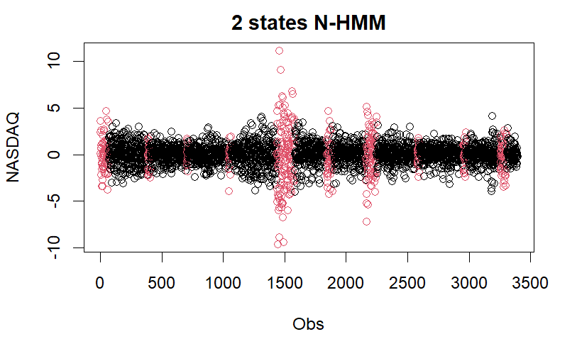

```r
plot(newDF[,1],
     col=HSMM[[1]]$model$yhat,
     main = "2 states N-HMM",
     xlab="Obs",
     ylab=colnames(newDF)[1])
```

```r
HSMM[[1]]$model$model$transition
```

```
     [,1] [,2]
[1,]    0    1
[2,]    1    0
```

```r
colSums(HSMM[[1]]$model$model$transition)/2
```

```
[1] 0.5 0.5
```

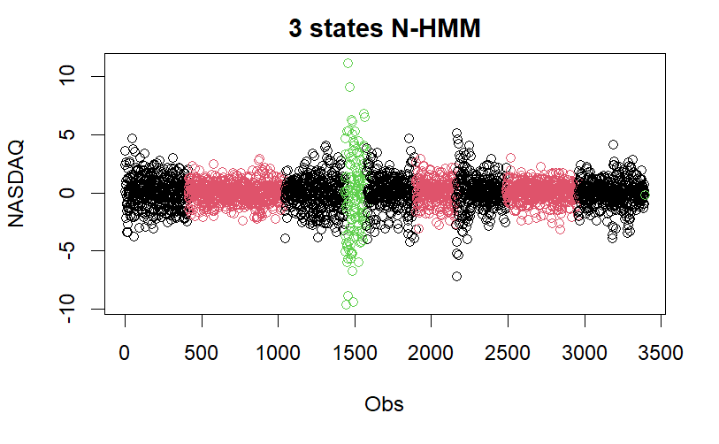

```r
plot(newDF[,1],
     col=HSMM[[2]]$model$yhat,
     main = "3 states N-HMM",
     xlab="Obs",
     ylab=colnames(newDF)[1])
```

```r
HSMM[[2]]$model$model$transition
```

```
     [,1]      [,2]      [,3]
[1,]    0 0.7136443 0.2863557
[2,]    1 0.0000000 0.0000000
[3,]    1 0.0000000 0.0000000
```

```r
colSums(HSMM[[2]]$model$model$transition)/3
```

```
[1] 0.66666667 0.23788144 0.09545189
```

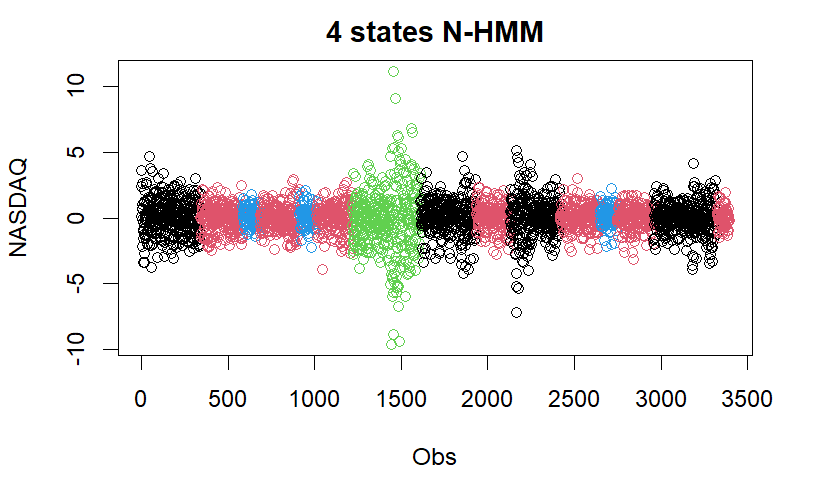

```r
plot(newDF[,1],
     col=HSMM[[3]]$model$yhat,
     main = "4 states N-HMM",
     xlab="Obs",
     ylab=colnames(newDF)[1])
```

```r
HSMM[[3]]$model$model$transition
```

```
              [,1] [,2]          [,3]          [,4]
[1,]  0.000000e+00    1 1.713164e-142 1.566188e-321
[2,]  3.333333e-01    0  1.666667e-01  5.000000e-01
[3,]  1.000000e+00    0  0.000000e+00  0.000000e+00
[4,] 2.509063e-279    1  0.000000e+00  0.000000e+00
```

```r
colSums(HSMM[[3]]$model$model$transition)/4
```

```
[1] 0.33333333 0.50000000 0.04166667 0.12500000
```

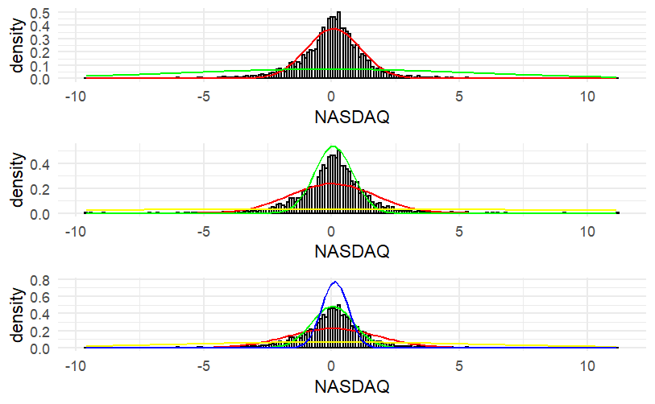

```r
p1<-ggplot(StockReturns2, aes(x=NASDAQ)) +
  geom_histogram(aes(y =..density..),
                 color="black", fill="white", binwidth=.1) +
  theme_minimal()+
  stat_function(fun = dnorm, args = list(mean = HSMM[[1]]$means.mean[1],
                                         sd = HSMM[[1]]$sigma.mean[1]), colour="red")+
  stat_function(fun = dnorm, args = list(mean = HSMM[[1]]$means.mean[3],
                                         sd = HSMM[[1]]$sigma.mean[5]), colour="green")

p2<-ggplot(StockReturns2, aes(x=NASDAQ)) +
  geom_histogram(aes(y =..density..),
                 color="black", fill="white", binwidth=.1) +
  theme_minimal()+
  stat_function(fun = dnorm, args = list(mean = HSMM[[2]]$means.mean[1],
                                         sd = HSMM[[2]]$sigma.mean[1]), colour="red")+
  stat_function(fun = dnorm, args = list(mean = HSMM[[2]]$means.mean[3],
                                         sd = HSMM[[2]]$sigma.mean[5]), colour="green")+
  stat_function(fun = dnorm, args = list(mean = HSMM[[2]]$means.mean[5],
                                         sd = HSMM[[2]]$sigma.mean[9]), colour="yellow")

p3<-ggplot(StockReturns2, aes(x=NASDAQ)) +
  geom_histogram(aes(y =..density..),
                 color="black", fill="white", binwidth=.1) +
  theme_minimal()+
  stat_function(fun = dnorm, args = list(mean = HSMM[[3]]$model$model$parms.emission$mu[[1]][1],
                                         sd = HSMM[[3]]$model$model$parms.emission$sigma[[1]][1]), colour="red")+
  stat_function(fun = dnorm, args = list(mean = HSMM[[3]]$model$model$parms.emission$mu[[2]][1],
                                         sd = HSMM[[3]]$model$model$parms.emission$sigma[[2]][1]), colour="green")+
  stat_function(fun = dnorm, args = list(mean = HSMM[[3]]$model$model$parms.emission$mu[[3]][1],
                                         sd = HSMM[[3]]$model$model$parms.emission$sigma[[3]][1]), colour="yellow")+
  stat_function(fun = dnorm, args = list(mean = HSMM[[3]]$model$model$parms.emission$mu[[4]][1],
                                         sd = HSMM[[3]]$model$model$parms.emission$sigma[[4]][1]), colour="blue")

grid.arrange(p1, p2, p3, ncol=1)
```

## 3.2 Gamma SD

```r
bootstrap.N.HSMM.GAMMA <- function(data, states, R) {
  master = list()
  cores <- ifelse(detectCores() > 6,
                  cores <- 6,
                  cores <- 4)
  cl <- makeCluster(cores)
  registerDoParallel(cl)
  master <- append(master, foreach(num = 2:states) %dopar% {
    require(mhsmm)

    hsmmAIC <- function(model) {
      if (class(model) == 'hmm') {
        m = model$K
      } else if (class(model) == 'hsmm') {
        m = model$J
      }
      k = length(model$model$parms.emission)
      p = m ^ 2 + (k * m) - 1
      logL = max(model$loglik)
      AIC = (2 * logL) + (2 * p)
      return(AIC)
    }

    hsmmBIC <- function(model) {
      if (class(model) == 'hmm') {
        m = model$K
      } else if (class(model) == 'hsmm') {
        m = model$J
      }
      nObs = length(model$yhat)
      k = length(model$model$parms.emission)
      p = (m ^ 2 + (k * m)) - 1
      logL = max(model$loglik)
      BIC = (2 * logL) + (p * log(nObs))
      return(BIC)
    }

    initialization <- kmeans(data, num)
    kmeans.means <- initialization$centers
    km.means.list = list()
    sigma.list = list()

    for (n in 1:num) {
      sigma.list[[n]] = cov(data[initialization$cluster == n, ])
      km.means.list[[n]] = kmeans.means[n, ]
    }

    K <- num
    P <- matrix(1 / (K - 1), ncol = K, nrow = K)
    diag(P) <- 0
    start.val <- hsmmspec(
      init = rep(1 / K, K),

      transition = P,

      parms.emis = list(mu = km.means.list,
                        sigma = sigma.list),

      sojourn = list(shape = as.vector(sample(1:100,K)),
                     scale = as.vector(sample(1:10,K)),
                     type = "gamma"),

      dens.emis = dmvnorm.hsmm,

      mstep = mstep.mvnorm)

    mod.hsmm <- hsmmfit(matrix(unlist(data),ncol = 2),
                        start.val, mstep = mstep.mvnorm)
    mu.boot <- matrix(NA, K * 2, R)
    sigma.boot <- matrix(NA, K * 4, R)
    for (b in 1:R){

      true.par <- hsmmspec(
        init = mod.hsmm$model$init,
        transition = mod.hsmm$model$transition,
        parms.emis = list(
          mu = mod.hsmm$model$parms.emission$mu,
          sigma = mod.hsmm$model$parms.emission$sigma),
        sojourn = list(
          shape = mod.hsmm$model$sojourn$shape,
          scale = mod.hsmm$model$sojourn$scale,
          type = mod.hsmm$model$sojourn$type),
        dens.emis = dmvnorm.hsmm,
        mstep = mstep.mvnorm)

      train <- simulate(true.par, nsim = 100, seed = b, rand.emis = rmvnorm.hsmm)

      mod.boot <- hsmmfit(train, true.par, mstep = mstep.mvnorm)
      mu.boot[, b] <- unlist(mod.boot$model$parms.emission$mu)
      sigma.boot[, b] <- unlist(mod.boot$model$parms.emission$sigma)
    }

    return(list(
      k = num,
      model = mod.hsmm,
      means.mean = t(matrix(apply(mu.boot, 1, mean), ncol = K * 2)),
      means.sd = t(matrix(apply(mu.boot, 1, sd), ncol = K * 2)),
      sigma.mean = t(matrix(apply(sigma.boot, 1, mean), ncol = K * 2 ** 2)),
      sigma.sd = t(matrix(apply(sigma.boot, 1, sd), ncol = K * 2 ** 2)),
      AIC = hsmmAIC(mod.hsmm),
      BIC = hsmmBIC(mod.hsmm)))
  }, length(master))

  stopCluster(cl)
  return(master)
}
load("~/N-HSMM-2-4-Gamma.RData")
```

```r
par(mfrow=c(3,1))
plot(GAMMA.HSMM[[1]]$model$loglik,
     type = "b",
     ylab="Log-likelihood",
     xlab="Iteration",
     xlim=c(0,30),
     main="2 states LogLik")
plot(GAMMA.HSMM[[2]]$model$loglik,
     type = "b",
     ylab = "Log-likelihood",
     xlab="Iteration",
     xlim=c(0,30),
     main="3 states LogLik")
```

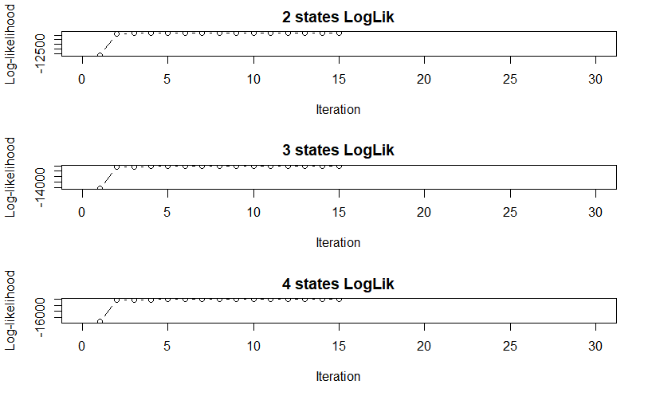

```r
plot(GAMMA.HSMM[[3]]$model$loglik,
     type = "b",
     ylab = "Log-likelihood",
     xlab="Iteration",
     xlim=c(0,30),
     main="4 states LogLik")
```

```r
par(mfrow=c(3,1))
plot(GAMMA.HSMM[[1]]$model,xlim=c(0,100))
plot(GAMMA.HSMM[[2]]$model,xlim=c(0,100))
```

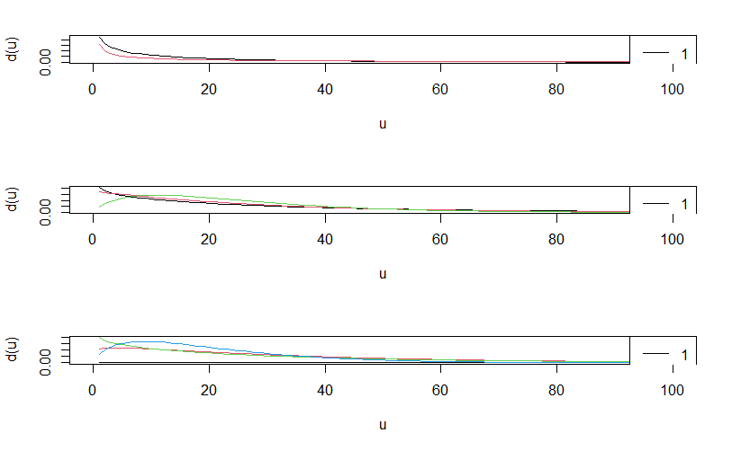

```r
plot(GAMMA.HSMM[[3]]$model,xlim=c(0,100))
```

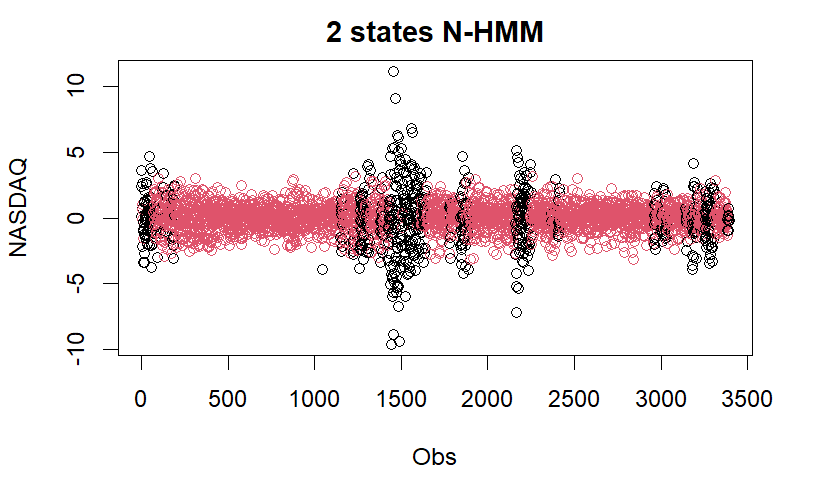

```r
plot(newDF[,1],
     col=GAMMA.HSMM[[1]]$model$yhat,
     main = "2 states N-HMM",
     xlab="Obs",
     ylab=colnames(newDF)[1])
```

```r
GAMMA.HSMM[[1]]$model$model$transition
```

```
     [,1] [,2]
[1,]    0    1
[2,]    1    0
```

```r
colSums(GAMMA.HSMM[[1]]$model$model$transition)/2
```

```
[1] 0.5 0.5
```

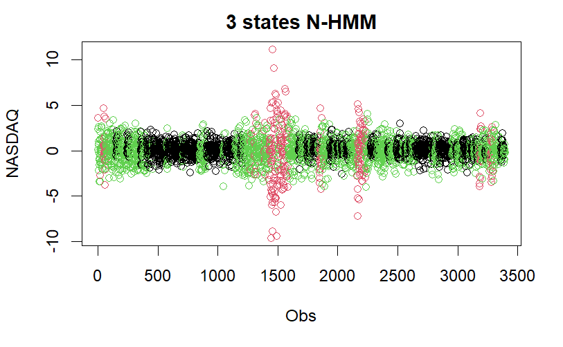

```r
plot(newDF[,1],
     col=GAMMA.HSMM[[2]]$model$yhat,
     main = "3 states N-HMM",
     xlab="Obs",
     ylab=colnames(newDF)[1])
```

```r
GAMMA.HSMM[[2]]$model$model$transition
```

```
             [,1]         [,2] [,3]
[1,] 0.000000e+00 1.321121e-09    1
[2,] 3.940354e-09 0.000000e+00    1
[3,] 8.025435e-01 1.974565e-01    0
```

```r
colSums(GAMMA.HSMM[[2]]$model$model$transition)/3
```

```
[1] 0.26751451 0.06581883 0.66666666
```

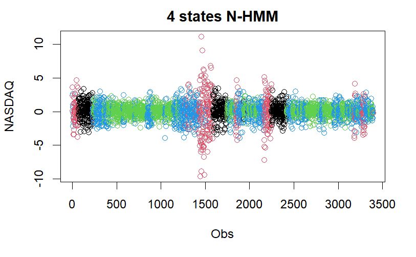

```r
plot(newDF[,1],
     col=GAMMA.HSMM[[3]]$model$yhat,
     main = "4 states N-HMM",
     xlab="Obs",
     ylab=colnames(newDF)[1])
```

```r
GAMMA.HSMM[[3]]$model$model$transition
```

```
             [,1]         [,2]         [,3]       [,4]
[1,] 0.000000e+00 3.244190e-14 0.9643304266 0.03566957
[2,] 2.906352e-01 0.000000e+00 0.0002904009 0.70907441
[3,] 2.097354e-27 2.190931e-07 0.0000000000 0.99999978
[4,] 2.560520e-27 2.103416e-01 0.7896584261 0.00000000
```

```r
colSums(GAMMA.HSMM[[3]]$model$model$transition)/4
```

```
[1] 0.07265880 0.05258545 0.43856981 0.43618594
```